# Welcome to EASI

[figure not shown]

This notebook introduces new users to working with EASI notebooks and the Open Data Cube.

It will demonstrate the following basic functionality:

- Notebook setup
- Connect to the OpenDataCube
  - List products
  - List measurements
  - Choose a region of interest
  - Load data
  - Plot data
  - Masking and Scaling
  - Perform a calculation on the data
  - Save the results to a file
- Summary
- Further reading

## Notebook setup

A notebook consists of cells that contain either text descriptions or python code for performing operations on data.

1. Start by clicking on the cell below to select it.
2. Execute a selected cell, or each cell in sequence, by clicking the "play" button (in the toolbar above) or pressing `Shift`+`Enter`.
3. Each cell will show an asterisk icon [*]: when it is running. Once this changes to a number, the cell has finished.
4. This cell below imports packages to use and sets some formatting options.

```python
%matplotlib inline

# Data tools
import numpy as np
import xarray as xr
import pandas as pd
from datetime import datetime
import matplotlib.pyplot as plt

# Formatting options
pd.set_option("display.max_rows", None)
# plt.rcParams['figure.figsize'] = [12, 8]

# Datacube
import datacube
from datacube.utils import masking  # https://github.com/opendatacube/datacube-core/blob/develop/datacube/utils/masking.py
from odc.algo import enum_to_bool   # https://github.com/opendatacube/odc-tools/blob/develop/libs/algo/odc/algo/_masking.py
from datacube.utils.aws import configure_s3_access

# Notebook helper tools (in dea_tools or in this repo)
import sys
from os import environ
repo = f'{environ["HOME"]}/eocsi-hackathon-2022'  # No easy way to get repo directory
if repo not in sys.path: sys.path.append(repo)
from tools.notebook_utils import xarray_object_size
try:
    from dea_tools.plotting import display_map, rgb
except ImportError:
    # Local copy of selected dea_tools
    from tools.datacube_utils import display_map
    rgb = None  # Not copied or adapted yet
```

## Connect to the OpenDataCube

The `Datacube()` API provides search, load and information functions for data products *indexed* in the EASI ODC database. For further information see https://datacube-core.readthedocs.io/en/latest/.

```python
# Initialise a datacube connection
dc = datacube.Datacube()

# Access AWS "requester-pays" buckets
configure_s3_access(aws_unsigned=False, requester_pays=True)

# Use EASI caching-proxy (applies to selected source buckets)
environ["AWS_HTTPS"] = "NO"
environ["GDAL_HTTP_PROXY"] = "easi-caching-proxy.caching-proxy:80"
print(f'Will use caching proxy at: {environ.get("GDAL_HTTP_PROXY")}')
```

```
Will use caching proxy at: easi-caching-proxy.caching-proxy:80
```

### List products

Get all available products in the ODC database and list them along with selected properties.

1. View available products and data coverage at the EASI Explorer: https://explorer.asia.easi-eo.solutions

```python
products = dc.list_products()  # Pandas DataFrame
products
```

| name | name | description | license | default_crs | default_resolution |
| --- | --- | --- | --- | --- | --- |
| copernicus_dem_30 | copernicus_dem_30 | Copernicus 30m Digital Elevation Model (GLO-30) | None | None | None |
| landsat5_c2l2_sr | landsat5_c2l2_sr | Landsat 5 Collection 2 Level-2 Surface Reflect... | None | None | None |
| landsat5_c2l2_st | landsat5_c2l2_st | Landsat 5 Collection 2 Level-2 UTM Surface Tem... | CC-BY-4.0 | None | None |
| landsat7_c2l2_sr | landsat7_c2l2_sr | Landsat 7 USGS Collection 2 Surface Reflectanc... | None | None | None |
| landsat7_c2l2_st | landsat7_c2l2_st | Landsat 7 Collection 2 Level-2 UTM Surface Tem... | CC-BY-4.0 | None | None |
| landsat8_c2l1 | landsat8_c2l1 | Landsat 8 Collection 2 Level-1 (top of atmosph... | CC-BY-4.0 | None | None |
| landsat8_c2l2_sr | landsat8_c2l2_sr | Landsat 8 Collection 2 Surface Reflectance, pr... | None | None | None |
| landsat8_c2l2_st | landsat8_c2l2_st | Landsat 8 Collection 2 Level-2 UTM Surface Tem... | CC-BY-4.0 | None | None |
| landsat9_c2l1 | landsat9_c2l1 | Landsat 9 Collection 2 Level-1 (top of atmosph... | CC-BY-4.0 | None | None |
| landsat9_c2l2_sr | landsat9_c2l2_sr | Landsat 9 Collection 2 Surface Reflectance, pr... | CC-BY-4.0 | None | None |
| landsat9_c2l2_st | landsat9_c2l2_st | Landsat 9 Collection 2 Level-2 UTM Surface Tem... | CC-BY-4.0 | None | None |
| lpdaac_nasadem | lpdaac_nasadem | NASADEM Merged DEM Global 1 arc second V001 | None | None | None |
| nasa_aqua_l2_oc | nasa_aqua_l2_oc | NASA MODIS-Aqua L2 Ocean Color, regridded to W... | None | EPSG:4326 | (0.01, 0.01) |
| nasa_aqua_l2_sst | nasa_aqua_l2_sst | NASA MODIS-Aqua L2 Sea Surface Temperature, re... | None | EPSG:4326 | (0.01, 0.01) |
| s2_l2a | s2_l2a | Sentinel-2a and Sentinel-2b imagery, processed... | None | None | None |

### List measurements

The data arrays available for each product are called "*measurements*".

1. List the "*measurements*" of the Landsat-8 surface reflectance product ("**landsat8_c2l2_sr**")
2. The columns are the "*attributes*" available for each "*measurement*"

```python
measurements = dc.list_measurements()  # Pandas DataFrame, all products
measurements.loc['landsat8_c2l2_sr']
```

| measurement | name | dtype | units | nodata | aliases | flags_definition |
| --- | --- | --- | --- | --- | --- | --- |
| coastal | coastal | uint16 | reflectance | 0 | [SR_B1, band_1, B1, coastal_aerosol] | NaN |
| blue | blue | uint16 | reflectance | 0 | [SR_B2, band_2, B2] | NaN |
| green | green | uint16 | reflectance | 0 | [SR_B3, band_3, B3] | NaN |
| red | red | uint16 | reflectance | 0 | [SR_B4, band_4, B4] | NaN |
| nir08 | nir08 | uint16 | reflectance | 0 | [SR_B5, band_5, B5, nir] | NaN |
| swir16 | swir16 | uint16 | reflectance | 0 | [SR_B6, band_6, B6, swir1] | NaN |
| swir22 | swir22 | uint16 | reflectance | 0 | [SR_B7, band_7, B7, swir2] | NaN |
| qa_pixel | qa_pixel | uint16 | bit_index | 1 | [pixel_quality, level2_qa, QA_PIXEL, pixel_qa] | {'snow': {'bits': 5, 'values': {'0': 'not_high... |
| qa_aerosol | qa_aerosol | uint8 | bit_index | 1 | [sr_aerosol, SR_QA_AEROSOL, aerosol_qa] | {'water': {'bits': 2, 'values': {'0': 'not_wat... |
| qa_radsat | qa_radsat | uint16 | bit_index | 1 | [saturation_qa, QA_RADSAT, radsat_qa] | {'qa_radsat': {'bits': [0, 1, 2, 3, 4, 5, 6, 7... |

### Choose a region of interest

See the available `latitude`/`longitude` and `time` ranges in the [ODC Explorer](https://explorer.asia.easi-eo.solutions/products/landsat8_c2l2_sr).

1. Feel free to change the `latitude`/`longitude` or `time` ranges of the query below.

```python
# hub.asia.easi-eo.solutions - Lake Tempe, Indonesia
latitude = (-4.2, -3.9)
longitude = (119.8, 120.1)
display_map(longitude, latitude)
```

Make this Notebook Trusted to load map: File -> Trust Notebook

[interactive chart not shown]

### Load data

Load Landsat-8 surface reflectance data ("**landsat8_c2l2_sr**") for a given latitude, longitude and time range.

> This may take a few minutes while the data are loaded into JupyterLab (so choose a small area and time range!).

The `datacube.load()` function returns an `xarray.Dataset` object.

- The display() view is a convenient way to check the data request size, shape and attributes
- Once you have an xarray object this can be used with many Python packages.

The `output_crs` and `resolution` parameters are dependent on the `product` chosen.

Further information on `xarray`: http://xarray.pydata.org/en/stable/user-guide/data-structures.html

```python
# A standard datacube.load() call
# Any SQLAlchemy warnings can be ignored.

data = dc.load(
    product = 'landsat8_c2l2_sr',
    latitude = latitude,
    longitude = longitude,
    time=('2020-02-01', '2020-04-01'),

    output_crs="EPSG:32655",  # Target CRS
    resolution=(30, -30),     # Target resolution
    group_by='solar_day',     # Group by time method
)

display(xarray_object_size(data))
display(data)
```

```
'Dataset size: 120.35 MB'
```

```
<xarray.Dataset>
Dimensions:      (time: 4, y: 1286, x: 1291)
Coordinates:
  * time         (time) datetime64[ns] 2020-02-10T02:10:17.788921 ... 2020-03...
  * y            (y) float64 -5.222e+05 -5.221e+05 ... -4.836e+05 -4.836e+05
  * x            (x) float64 -2.601e+06 -2.601e+06 ... -2.64e+06 -2.64e+06
    spatial_ref  int32 32655
Data variables:
    coastal      (time, y, x) uint16 8203 7860 8172 8332 ... 11387 11498 11471
    blue         (time, y, x) uint16 8579 8101 8434 8662 ... 11459 11543 11542
    green        (time, y, x) uint16 9795 9583 9859 10183 ... 12887 12939 12823
    red          (time, y, x) uint16 9550 9115 9580 9974 ... 12978 13125 13015
    nir08        (time, y, x) uint16 21181 19938 19005 ... 20020 20151 20301
    swir16       (time, y, x) uint16 15521 14502 15444 ... 11572 11694 11635
    swir22       (time, y, x) uint16 11529 10801 11726 ... 10941 11000 10982
    qa_pixel     (time, y, x) uint16 21824 21824 21824 ... 22280 22280 22280
    qa_aerosol   (time, y, x) uint8 160 160 160 160 160 ... 224 224 224 224 224
    qa_radsat    (time, y, x) uint16 0 0 0 0 0 0 0 0 0 0 ... 0 0 0 0 0 0 0 0 0 0
Attributes:
    crs:           EPSG:32655
    grid_mapping:  spatial_ref
```

### Plot data

Plot the [Short-wave Infrared (SWIR)](https://www.usgs.gov/faqs/what-are-best-landsat-spectral-bands-use-my-research) (`"swir22"`) band data at each timestep.

The `datacube.load()` function does not apply missing values or scaling attributes. These are left to the user's discretion and requirements.

- The robust option excludes outliers when calculating the colour limts for a more consistent result.

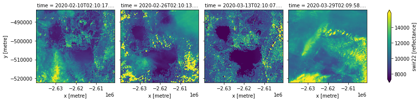

```python
# Xarray operations
band = 'swir22'
data[band].plot(col="time", robust=True, col_wrap=4);
```

### Masking and Scaling

Many Earth observation products include a "quality" array that can be used to filter the measurement arrays. For example, most quality layers include a "cloud" confidence quality flag that can be use to remove pixels affected by clouds from further analysis. In addition:

- Data products usually include a `nodata` value that defines the "null" or "fill" value used in the array, and;
- Some data products may also have "scaling" attributes.

More information on these techniques is covered in other notebooks. In particular, see the `datasets/*ipynb` notebooks for specific examples.

**Landsat** data requires a scale factor to be applied to convert the data to physical reflectance or temperature values. Once converted, Landsat surface reflectance values will have numbers ranging from 0 to 1 and surface temperature values will be in the units of degrees Kelvin. The scaling factor is different for different Landsat "Collections" and it is different for the Surface Reflectance and Surface Temperature products. See https://www.usgs.gov/faqs/how-do-i-use-a-scale-factor-landsat-level-2-science-products.

In the cell below we:

1. Apply the `nodata` value
2. Define and apply the Landsat "Collection 2" surface reflectance scaling values.
3. Apply a cloud mask

Note the exclusion of cloud (if present) and the change in the colourbar range from the previous figure.

```python
# Choose bands for further processing
bands = ['red', 'green', 'blue', 'nir08', 'swir22']

# Make a mask array for the nodata value
valid_mask = masking.valid_data_mask(data[bands])

# Define the scaling values (landsat8_c2l2_sr)
scale_factor = 0.0000275
add_offset = -0.2

# Make a scaled data array
scaled_data = data[bands] * scale_factor + add_offset
```

```python
# Make a cloud mask (landsat8_c2l2_sr)
from datacube.utils import masking

# Optional - Show the flag_definition information
# See also http://explorer.asia.easi-eo.solutions/products/landsat8_c2l2_sr#definition-doc
# display( masking.describe_variable_flags(data.qa_pixel) )

# Multiple flags are combined as logical AND (bitwise)
cloud_mask = masking.make_mask(data['qa_pixel'],
    clear='clear',
)
```

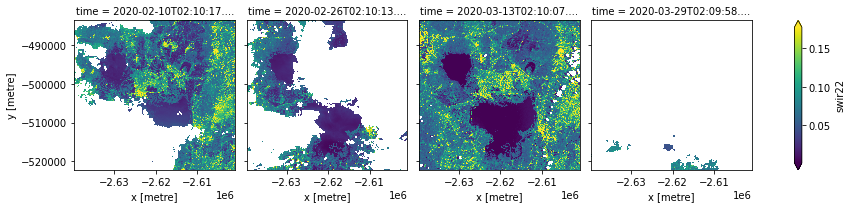

```python
# Apply each of the masks
filtered_data = scaled_data.where(valid_mask & cloud_mask)

filtered_data['swir22'].plot(col="time", robust=True, col_wrap=4);
```

### Perform a calculation on the data

As a simple example, we calculate the Normalized Difference Vegetation Index (NDVI).

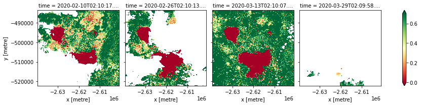

```python
# Calculate the NDVI
band_diff = filtered_data.nir08 - filtered_data.red
band_sum = filtered_data.nir08 + filtered_data.red
ndvi = band_diff / band_sum

# Plot the masked NDVI
ndvi.plot(col="time", robust=True, col_wrap=4, vmin=0, vmax=0.7, cmap='RdYlGn');
```

### Save the results to file

After processing the data we can then save the output to a file that can then be imported into other applications for further analysis or publication if required.

The file will be saved to your home directory and appear on the File Browser panel to the left. You may need to select the `folder` icon to go to the top level (`/home/jovyan/`).

Download a file by `'right-click' Download`.

```python
# Xarray can save the data to a netCDF file

ndvi.time.attrs.pop('units', None)  # Xarray re-applies this
ndvi.to_netcdf("/home/jovyan/landsat8_sr_ndvi.nc")
```

```python
# Or export to geotiff using rioxarray.

import rioxarray
ndvi.isel(time=0).rio.to_raster("/home/jovyan/landsat8_sr_ndvi.tif")  # Single time slices
```

## Summary

This notebook introduced the main steps for querying data (with `Datacube`), and filtering, plotting, calculating and saving a "cube" of data (with `Xarray`).

There is plenty of detail and options to explore so please work through the other notebooks to learn more and refer back to these notebooks when required. We encourage you to create or bring your own notebooks, and adapt notebooks from other [open-license repositories](https://docs.asia.easi-eo.solutions/user-guide/users-guide/03-using-notebooks/#other-available-odc-notebooks).

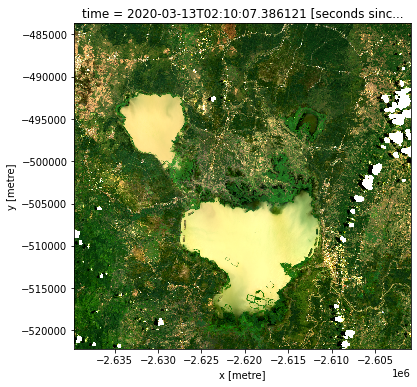

```python
if rgb:
    rgb(filtered_data.isel(time=2), ['red', 'green', 'blue'])
```

## Further reading

#### Open Data Cube

- [ODC documentation](https://datacube-core.readthedocs.io/en/latest)
- [ODC github](https://github.com/opendatacube)

#### Python

> *Recommended level: Basic Python knowledge and familiarity with array manipulations, **numpy** and **xarray**. Familiarity with some plotting libraries (e.g., **matplotlib**) would also help.*

There are many options for learning Python from online resources to in-house or facilitated training. Some examples are offered here with no suggestion that EASI endorses any of them.

- https://www.python.org/about/gettingstarted
- Learn Python tutorials: https://www.learnpython.org
- Data Camp: https://www.datacamp.com
- David Beazley courses: https://dabeaz-course.github.io/practical-python
- Python Charmers: https://pythoncharmers.com

Background for selected libraries:

- Numpy: https://numpy.org/doc/stable/user/quickstart.html
- Xarray: http://xarray.pydata.org/en/stable/user-guide/data-structures.html
- Xarray: https://towardsdatascience.com/basic-data-structures-of-xarray-80bab8094efa

#### JupyterLab

> *Recommended level: Familiarity with notebooks.*

The JupyterLab website has excellent documentation including video instructions. We recommend users take a few minutes to orientate themselves with the use and features of JupyterLab.

- Getting started: https://jupyterlab.readthedocs.io/en/stable/getting_started/overview.html
- Drag and drop upload of files: https://jupyterlab.readthedocs.io/en/stable/user/files.html

#### Git

> *Recommended level: Basic understanding of concepts such as **clone**, **add**, **commit** and **push** would help.*

Git is a document version control system. It retains a full history of changes to all files (including deleted ones) by tracking incremental changes and recording a history timeline of changes. Changes you make append to the history timeline. Git allows you to copy ("clone") a repository, make changes to files, and "commit" and "push" these changes back to the source repository.

The best way to learn Git is by practice and incrementally; start with simple, common actions and gain more knowledge when required. Some useful Git links are:

- Getting started: https://git-scm.com/doc
- Using the JupyterLab Git extension: https://annefou.github.io/jupyter_publish/02-git/index.html
- DEA Git guide: https://github.com/GeoscienceAustralia/dea-notebooks/wiki/Guide-to-using-DEA-Notebooks-with-git
- Undoing things guide: https://git-scm.com/book/en/v2/Git-Basics-Undoing-Things
- Understanding branches: https://nvie.com/posts/a-successful-git-branching-model